# Linear and Nonlinear Regression

Author

Shrikar Banagiri

Published

November 8, 2023

## Introduction

- `dteday`: The date.
- `season`: season (1 represents winter, 2 represents spring, 3 represents summer, 4 represents fall).
- `yr`: year (0 represents 2011, 1 represents 2012).
- `mnth`: month (1 to 12).
- `hr`: hour (0 to 23).
- `holiday`: whether day is a holiday or not (0 represents not a holiday, 1 represents a holiday).
- `weekday`: the day of the week (0 for Sunday and 6 Saturday).
- `workingday`: if working day, the value is 1; else the value is 0.
- `weathersit`: 1 represents clear weather, 2 represents mist / mist + broken clouds / mist + few clouds, 3 represents light snow / light rain, 4 represents heavy rain + thunderstorm + ice pallets / snow + fog.
- `temp`: this represents the normalized temperature in $^{\circ}$C.
- `atemp`: this represents the normalized “feels like” temperature in $^{\circ}$C.
- `hum`: Normalized humidity, ranges from 0 - 1.
- `windspeed`: Normalized windspeed, ranges from 0 - 1.
- `casual`: the number of casual bikers.
- `registered`: the number of registered bikers.
- `cnts`: the total number of casual and registered bikes.

The problem statement is to predict the total number of both casual and registered bikes `cnts` given the values of the rest of the features.

## Importing the dataset

The dataset is hosted on the [UC Irvine Machine Learning Repository](https://archive.ics.uci.edu/). First, we import the libraries required to perform the analysis.

```python
# Import the libraries

import numpy as np
import pandas as pd
import seaborn as sns
import matplotlib.pyplot as plt
import urllib.request
from pathlib import Path
import os
import zipfile

# Downloading and opening the dataset

csv_path = Path('datasets/bike+sharing+dataset.zip') # store the dataset in a local folder
url = 'https://archive.ics.uci.edu/static/public/275/bike+sharing+dataset.zip' # url to download the dataset

if not csv_path.is_file(): # check if the dataset directory exists.
  Path("datasets").mkdir(parents=True,exist_ok=True) # Create the directory
  urllib.request.urlretrieve(url, csv_path)
  with zipfile.ZipFile(csv_path) as bike_file:
    bike_file.extractall(path='datasets')

bike_sharing_day = pd.read_csv(Path('datasets/day.csv'))
bike_sharing_hour = pd.read_csv(Path('datasets/hour.csv')) # Store the dataset in a variable
```

## Analyzing the data

Let us survey the data by using the `info()` method below. As we can see, there are no null entries in this dataset.

```python
bike_sharing_hour.info()
```

```
<class 'pandas.core.frame.DataFrame'>
RangeIndex: 17379 entries, 0 to 17378
Data columns (total 17 columns):
 #   Column      Non-Null Count  Dtype
---  ------      --------------  -----
 0   instant     17379 non-null  int64
 1   dteday      17379 non-null  object
 2   season      17379 non-null  int64
 3   yr          17379 non-null  int64
 4   mnth        17379 non-null  int64
 5   hr          17379 non-null  int64
 6   holiday     17379 non-null  int64
 7   weekday     17379 non-null  int64
 8   workingday  17379 non-null  int64
 9   weathersit  17379 non-null  int64
 10  temp        17379 non-null  float64
 11  atemp       17379 non-null  float64
 12  hum         17379 non-null  float64
 13  windspeed   17379 non-null  float64
 14  casual      17379 non-null  int64
 15  registered  17379 non-null  int64
 16  cnt         17379 non-null  int64
dtypes: float64(4), int64(12), object(1)
memory usage: 2.3+ MB
```

Let us now look at the counts of the individual dates.

```python
bike_sharing_hour['dteday'].value_counts()
```

```
dteday
2011-01-01    24
2012-04-03    24
2012-04-28    24
2012-04-29    24
2012-04-30    24
              ..
2011-01-26    16
2011-01-18    12
2012-10-30    11
2011-01-27     8
2012-10-29     1
Name: count, Length: 731, dtype: int64
```

As shown in the value counts of the dates, not all hours of all dates are recorded. For example, on 29 October 2012, data for only one hour is available. Furthermore, we need to convert the `dteday` column into a `datetime` format. Furthermore, we will split the dates into separate columns comprising days, months, and years.

```python
bike_sharing_hour['dteday'] = pd.to_datetime(bike_sharing_hour['dteday']) # convert to date time format
bike_sharing_hour['day'] = bike_sharing_hour['dteday'].dt.day # split into days
bike_sharing_hour = bike_sharing_hour.drop('dteday',axis=1) # Drop the dteday column
```

Next, drop the irrelevant and redundant features. The `instant` column just represents an index, `atemp` is just a modification of the `temp` feature, `casual` and `rental` are just subsets of the `cnt` feature. `holiday` and `weekday` are together described by the feature `workingday.` Thus, we will drop all these features.

```python
bike_sharing_hour = bike_sharing_hour.drop(['instant','holiday','weekday','atemp','casual','registered'],axis=1) # drop the irrelevant columns
```

Let us now look at the correlation matrix for this dataset.

```python
corr_matrix = bike_sharing_hour.corr() # correlation matrix
corr_matrix['cnt'].sort_values(ascending=False) # see the linear correlation values for the counts feature
```

```
cnt           1.000000
temp          0.404772
hr            0.394071
yr            0.250495
season        0.178056
mnth          0.120638
windspeed     0.093234
workingday    0.030284
day          -0.004312
weathersit   -0.142426
hum          -0.322911
Name: cnt, dtype: float64
```

As shown in the matrix, the `day` feature has a very weak correlation with the `cnt` feature. Thus, we can drop this feature

```python
bike_sharing_hour = bike_sharing_hour.drop('day',axis=1)
```

Let us look at the correlation matrix for our dataframe now.

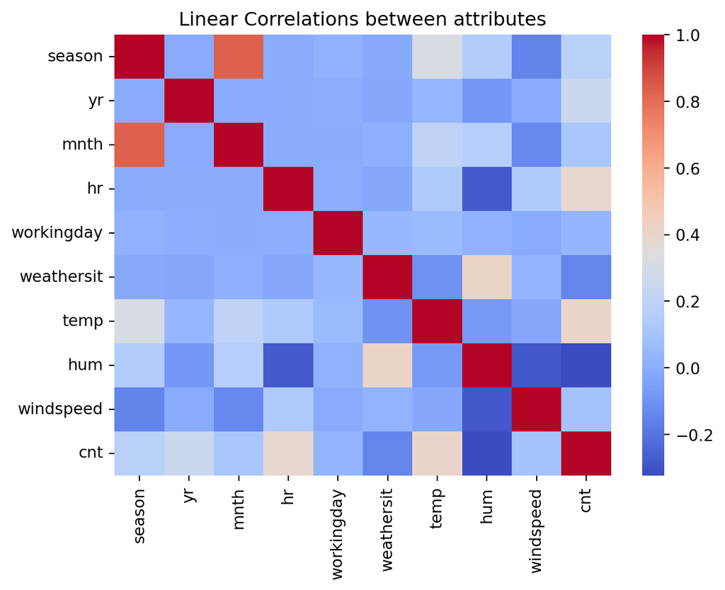

```python
corr = bike_sharing_hour.corr() # correlation matrix
sns.heatmap(corr,cmap='coolwarm')
plt.title('Linear Correlations between attributes')
plt.show()
```

```python
bike_sharing_hour = bike_sharing_hour.drop('mnth',axis=1) # drop the month feature from the dataset
```

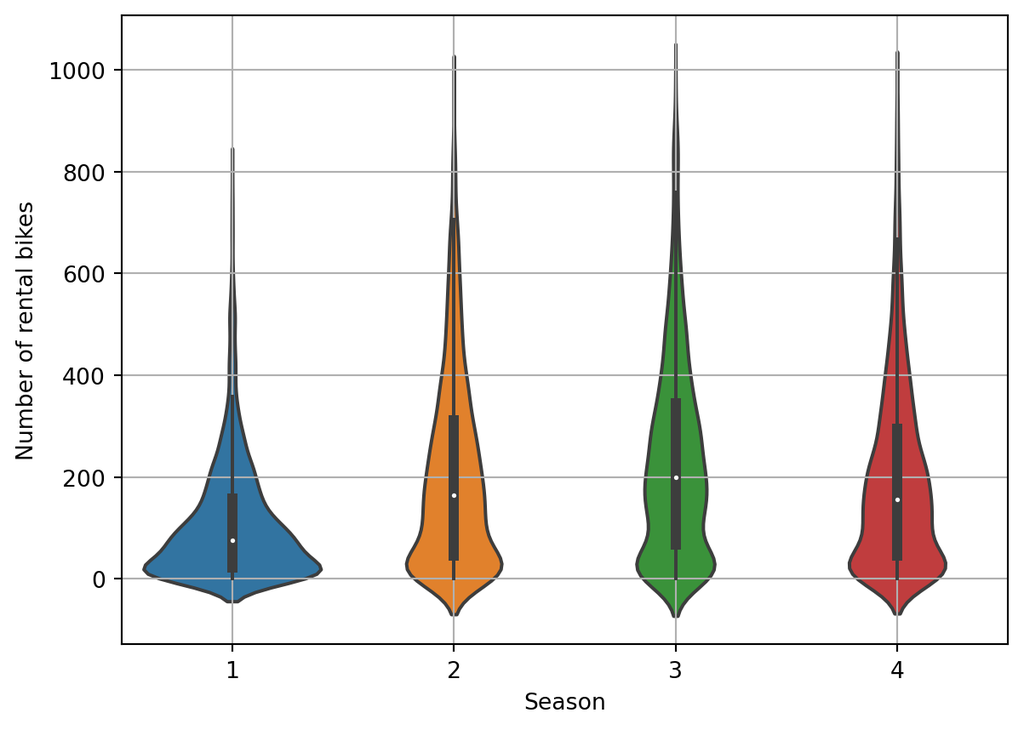

Since we have categorical attributes in our dataset, we will need to do one hot encoding as shown below.

```python
from sklearn.preprocessing import OneHotEncoder

cat_encoder = OneHotEncoder()
bike_cats = bike_sharing_hour[['season','weathersit']] # categorical columns segregation
cat_array_encoded = cat_encoder.fit_transform(bike_cats)
bike_cats_encoded = pd.DataFrame(cat_array_encoded.toarray(),columns=cat_encoder.get_feature_names_out()) # encoded dataframe

frames = [bike_sharing_hour, bike_cats_encoded]
bike_sharing_hour_encoded = pd.concat(frames,axis=1) # encode the categorical variable in the original data frame
bike_sharing_hour_encoded = bike_sharing_hour_encoded.drop(['season','weathersit'],axis=1) # drop redundant columns
```

Let us look at the distributions of the non-categorical features in the dataset.

```
array([[<Axes: title={'center': 'temp'}>,
        <Axes: title={'center': 'hum'}>],
       [<Axes: title={'center': 'windspeed'}>, <Axes: >]], dtype=object)
```

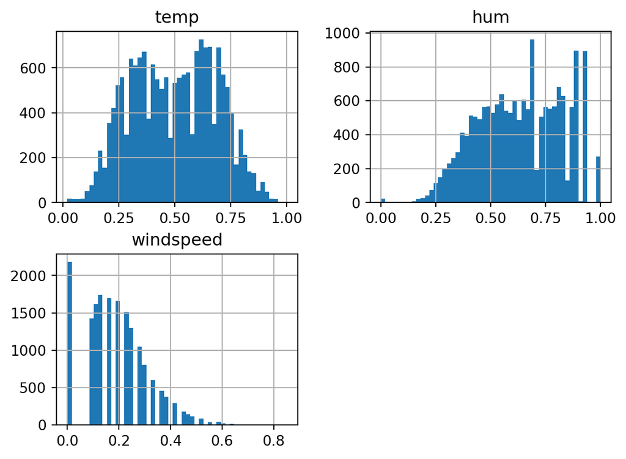

```python
bike_features = bike_sharing_hour_encoded[['temp','hum','windspeed']] # non-categorical features in the DataFrame
bike_features.hist(bins=50) # histogram
```

As we can see from the distributions, the `temp` feature has a gaussian like distribution whereas `hum` and `windspeed` are not gaussian. Thus, we will use the `StandardScaler` and `boxcox` transformer were used to transform these features.

```
array([[<Axes: title={'center': 'temp'}>,
        <Axes: title={'center': 'hum'}>],
       [<Axes: title={'center': 'windspeed'}>, <Axes: >]], dtype=object)
```

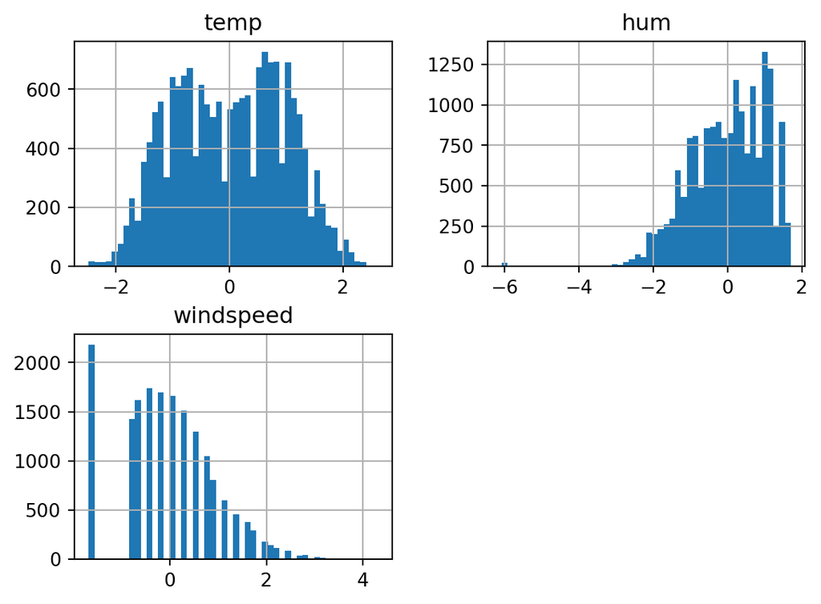

```python
from sklearn.preprocessing import StandardScaler
from scipy.stats import boxcox
from sklearn.preprocessing import MinMaxScaler

min_max_scaler = MinMaxScaler(feature_range=(1,2))
std_scaler = StandardScaler()

bike_sharing_hour_encoded[['windspeed']] = min_max_scaler.fit_transform(bike_sharing_hour_encoded[['windspeed']])
bike_sharing_hour_encoded[['windspeed']] = boxcox(bike_sharing_hour_encoded[['windspeed']],0)
bike_sharing_hour_encoded[['hum']] = boxcox(bike_sharing_hour_encoded[['hum']],0.5) # boxcox transform to scale hum feature
bike_sharing_hour_encoded[['temp']] = std_scaler.fit_transform(bike_sharing_hour_encoded[['temp']])
bike_sharing_hour_encoded[['hum']] = std_scaler.fit_transform(bike_sharing_hour_encoded[['hum']])
bike_sharing_hour_encoded[['windspeed']] = std_scaler.fit_transform(bike_sharing_hour_encoded[['windspeed']])# Standardize the features

bike_features = bike_sharing_hour_encoded[['temp','hum','windspeed']]
bike_features.hist(bins=50) # histogram
```

The histograms now show a fairly gaussian distribution except for a few outliers in the `hum` feature. Let us remove these outliers.

```
array([[<Axes: title={'center': 'temp'}>,
        <Axes: title={'center': 'hum'}>],
       [<Axes: title={'center': 'windspeed'}>, <Axes: >]], dtype=object)
```

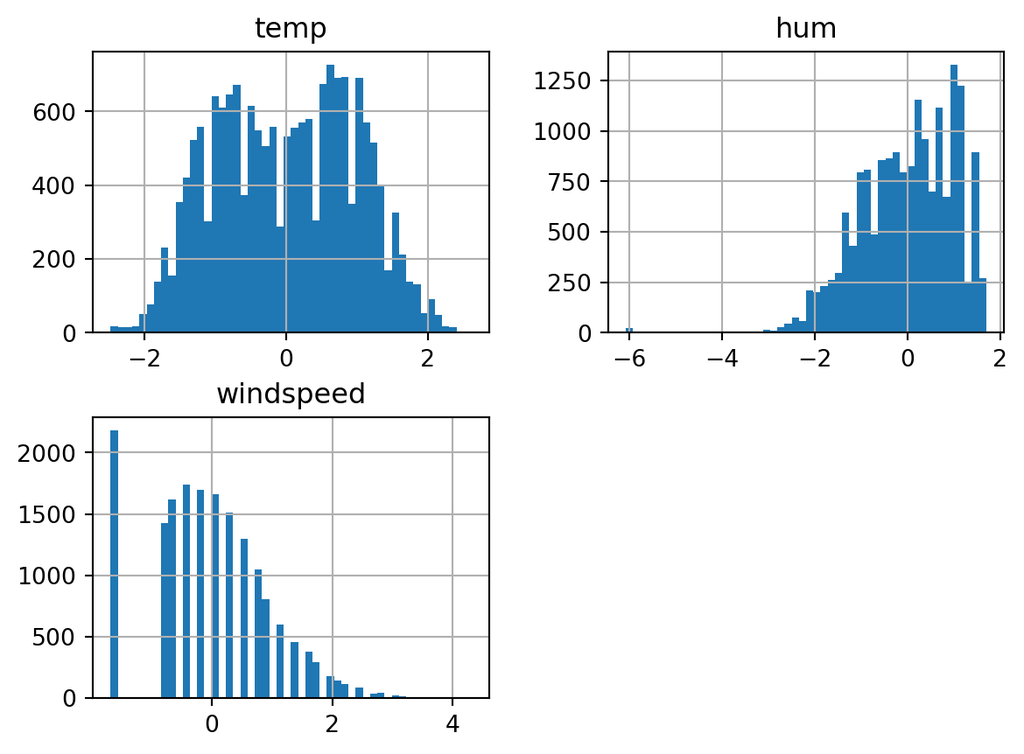

```python
hum_outliers = bike_sharing_hour_encoded[bike_sharing_hour_encoded.hum == -6.0] # outliers in the humidity features
bike_new = bike_sharing_hour_encoded.merge(hum_outliers,how='left',indicator=True)
bike_new = bike_new[bike_new['_merge']=='left_only']

bike_new = bike_new.drop(['_merge'],axis=1)
bike_sharing_hour_encoded = bike_new # removed humidity outliers

bike_features = bike_sharing_hour_encoded[['temp','hum','windspeed']]
bike_features.hist(bins=50) # plot histogram again
```

## Creating Training and Test sets

Now, let us create the training and test sets as shown below.

```python
from sklearn.model_selection import train_test_split

train_set, test_set = train_test_split(bike_sharing_hour_encoded,test_size=0.2,random_state=42) # split the training and test sets

X_train = train_set.drop('cnt',axis=1) # drop the target label from the training set
y_train = train_set['cnt'] # target label
X_test = test_set.drop('cnt',axis=1) # drop the target label from the test set
y_test = test_set['cnt'] # target label
```

## Training the models

For this regression problem, let us use linear regression and non-linear regression models. Let us first try the simplest regression, the `LinearRegression`.

```python
from sklearn.linear_model import LinearRegression
from sklearn.model_selection import cross_val_score

lin_reg = LinearRegression()
lin_reg.fit(X_train,y_train) # Train the model

-cross_val_score(lin_reg,X_train,y_train,cv=5,scoring='neg_root_mean_squared_error')
```

```
array([138.25778269, 142.84438603, 139.61695447, 146.46972741,
       141.99234977])
```

For five-fold cross validation, `LinearRegression` produces a root mean squared error (RMSE) of about 140 on average. Let us look at the learning curve to see if the model is overfitting or underfitting the training data.

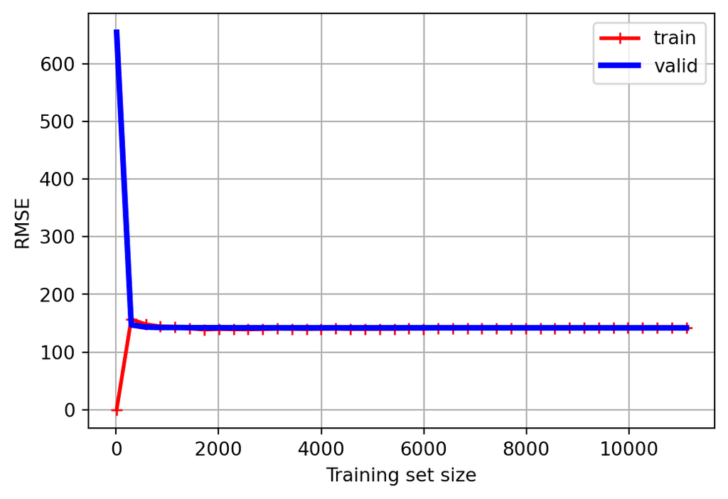

```python
# import learning_curve to check if the model is overfitting or underfitting

from sklearn.model_selection import learning_curve

train_sizes, train_scores, valid_scores = learning_curve(LinearRegression(), X_train, y_train, train_sizes=np.linspace(0.001, 1.0, 40), cv=5, scoring="neg_root_mean_squared_error") # learning curve for different test sizes

train_errors = -train_scores.mean(axis=1)
valid_errors = -valid_scores.mean(axis=1)

plt.figure(figsize=(6, 4)) # plot the learning curve
plt.plot(train_sizes, train_errors, "r-+", linewidth=2, label="train")
plt.plot(train_sizes, valid_errors, "b-", linewidth=3, label="valid")

plt.xlabel("Training set size")
plt.ylabel("RMSE")
plt.grid()
plt.legend(loc="upper right")
plt.show()
```

The learning curve plot shows a classic case of the model underfitting the data. When the training set data size is low, the data can be described fairly accurately by a linear regression model. Therefore, the RMSE is low for lower training set size. However, as the training set data size increases, the value of RMSE steadily increases until it reaches a constant value. At the point, adding or removing the training data does not make the model better or worse. Similarly, for the validation sets, if the size of the data set is low, the validation error is very high. However, as more data is added, the validation drops down until it reaches a constant value.

Since the model is underfitting, we will implement a higher degree polynomial regressor. We will import `PolynomialFeatures` from scikit-learn.

```python
from sklearn.preprocessing import PolynomialFeatures

poly_features = PolynomialFeatures(degree=2,include_bias=False)
X_poly_train = poly_features.fit_transform(X_train) # transform feature labels into the polynomial form
lin_reg.fit(X_poly_train,y_train) # fit linear regression on the polynomially transformed variables

-cross_val_score(lin_reg,X_poly_train,y_train,cv=5,scoring='neg_root_mean_squared_error') # the cross validation score
```

```
array([119.09738289, 121.77779834, 121.89287345, 124.76923189,
       120.9170965 ])
```

We can see that the polynomial regressor has performed marginally better than the linear regressor with an average cross val score of 120 across the 5 folds. Let us plot the learning curve to see whether the model is overfitting or underfitting.

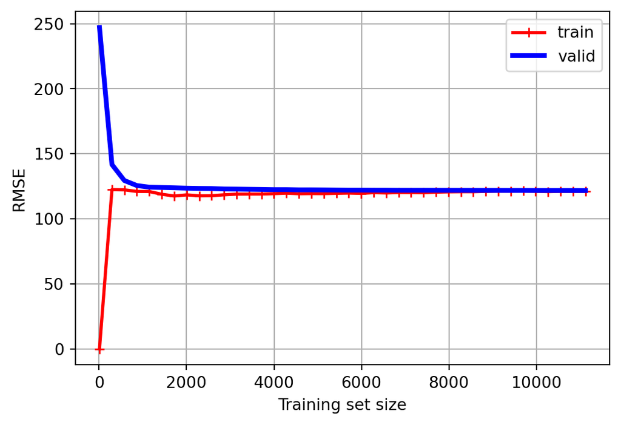

As we can see from the learning curve, the regression model is still underfitting. Therefore, let us use nonlinear regressors instead. We will use `DecisionTreeRegressor` first. We will use `RandomizedSearchCV` to tune the hyperparameters.

```python
from sklearn.tree import DecisionTreeRegressor
from sklearn.model_selection import RandomizedSearchCV
from scipy.stats import randint

decision_reg = DecisionTreeRegressor(random_state=42)
param_random = [{'max_depth':randint(low=2,high=20)},{'min_samples_leaf':randint(low=2,high=20)}] # hyperparameter tuning
rand_dec_reg = RandomizedSearchCV(decision_reg,param_distributions=param_random,scoring='neg_root_mean_squared_error',n_iter=10,random_state=42)
rand_dec_reg.fit(X_train,y_train) # training the decision tree regressor

-cross_val_score(rand_dec_reg,X_train,y_train,cv=5,scoring='neg_root_mean_squared_error')
```

```
array([57.64518755, 59.89346893, 58.21764267, 56.4518072 , 61.12587745])
```

The cross validation score for this model is close to 60 on average across the five validation folds. This score is much better than the linear and polynomial regressors. Let us look at the learning curve for this model.

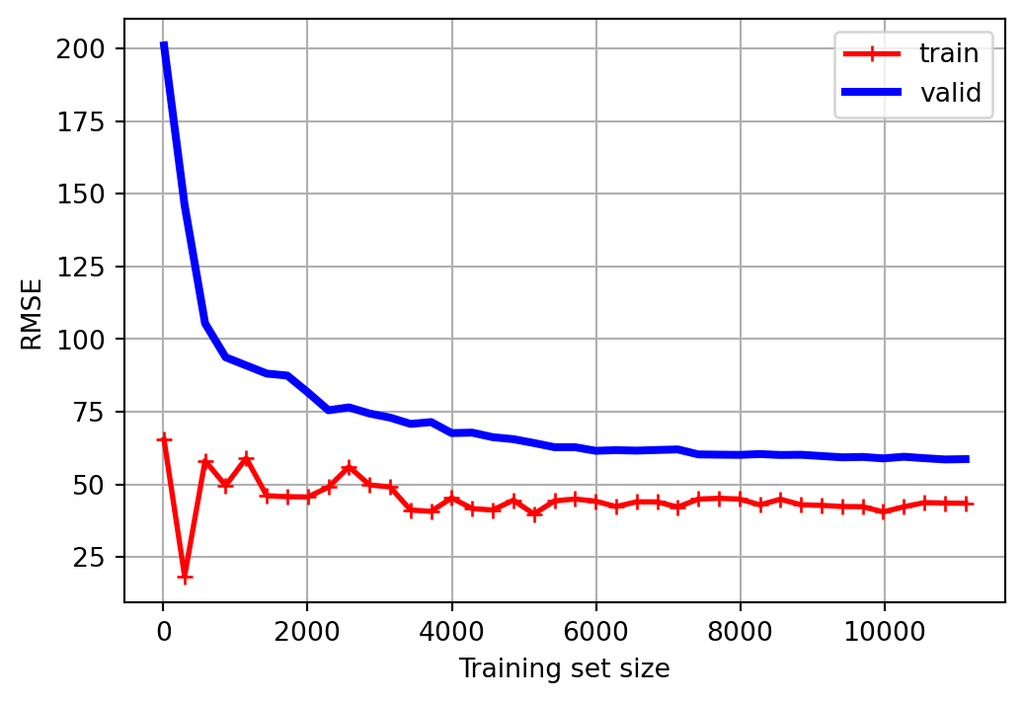

The validation error decreases as the training set size increases but the validation error never approaches the training error. Thus, the model seems to be slightly overfitting. Let us now implement the `RandomForestRegressor`.

```python
from sklearn.ensemble import RandomForestRegressor

rand_reg = RandomForestRegressor(random_state=42)
param_random = [{'n_estimators':randint(low=20,high=100)}] # hyperparameter tuning
random_rand_reg = RandomizedSearchCV(rand_reg,param_distributions=param_random,scoring='neg_root_mean_squared_error',n_iter=10,random_state=42)
random_rand_reg.fit(X_train,y_train) # training the decision tree regressor

-cross_val_score(random_rand_reg,X_train,y_train,cv=3,scoring='neg_root_mean_squared_error')
```

```
array([51.27749959, 48.82450026, 51.86218269])
```

The `RandomForestRegressor` produces a cross validation score of 50 on average across the three validation folds. Thus, the `RandomForestRegressor` performs the best among all the models tested here. Let us look at the root mean log squared error (RMLSE) for the test set using this model.

```python
from sklearn.metrics import mean_squared_log_error

y_pred = random_rand_reg.predict(X_test) # predictions on the test set
np.sqrt(mean_squared_log_error(y_pred,y_test))
```

```
0.3858129750838661
```

The RMLSE of the `RandomForestRegressor` is 0.386.

## Feature Importances

Let us look at how the RandomForestRegressor weighs the features in predictions. As shown in the bar plot below, the hour of the day is the most important feature for the Random Forest model.

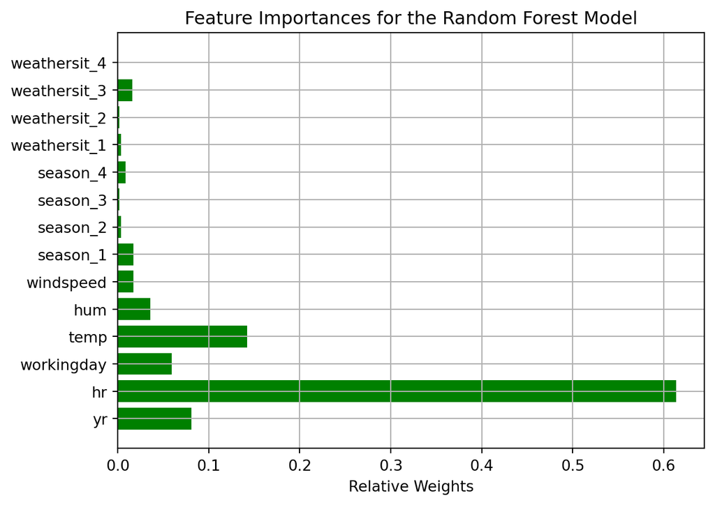

```python
importances = random_rand_reg.best_estimator_.feature_importances_
plt.title('Feature Importances for the Random Forest Model')
plt.barh(range(len(importances)), importances, color='g', align='center')
plt.yticks(range(len(importances)), X_train.columns)
plt.xlabel('Relative Weights')
plt.grid()
plt.show()
```